# 火祭聚类结果

康杰锋

## 引言

基于大可提供的火祭各类属性，对155个火祭进行分类，作为抽样调查的准备工作。由于属性类别比较复杂，例如资材使用量是连续变量，时间月份是分类变量，发生场所是分类或者二分类变量，因此一方面会对属性原始数据进行处理，另一方面会尝试采用不同方法进行聚类，可以比较看哪种方式更加合理。以及，我目前将分类类别设定为4类，如果需要修改设置，可以跟我说。

## 方法1：直接聚类

根据你提供的数据，直接采用层次聚类法进行分类。结果参见"clust_res_1_wrong_data.csv"和图"clust_res_1_wrong_data.png"。这是基于原本有点小问题（已经在微信上更正）进行的直接聚类，但是由于这个方法并不十分合理（比如祭典类别中包含复合类别，实际上应该重新编码比较合理），而且原本的代码已经被迭代，所以就没有重新出结果。从结果上也可以看出，这个聚类方法下，有一类（图中蓝色部分）中的案例非常少。

## 方法2：重编码再分类

正如上面提到，有些属性中包含多个数值，需要重新编码，因此做了如下处理：对于"類型"，如果涉及多个类型，则编码为"复合式"；对于"神社寺院"，由于大多数都包含多个类型地点，因此将其拆分成和后面神社寺院之外地点类似的形式。重编码后部分数据如下。

[output not shown]

在重编码后，和方法1类似地，采用层次聚类法进行分类。结果见"clust_res_2.png"和"clust_res_2.csv"。可见相比于方法1，现在分类的结果中，各类的案例数比较均衡。

## 方法3：PCA+层次聚类

有些属性关系比较紧密，例如神社寺院拆分后的各类，以及非神社寺院的各地点列。因此，可以首先对这些关系较紧密的列进行聚类降维，然后再结合其他属性，采用层次聚类法进行分类。

首先，对神社寺院各列进行主成分分析降维。降维后得到的前2个主成分结果如下。

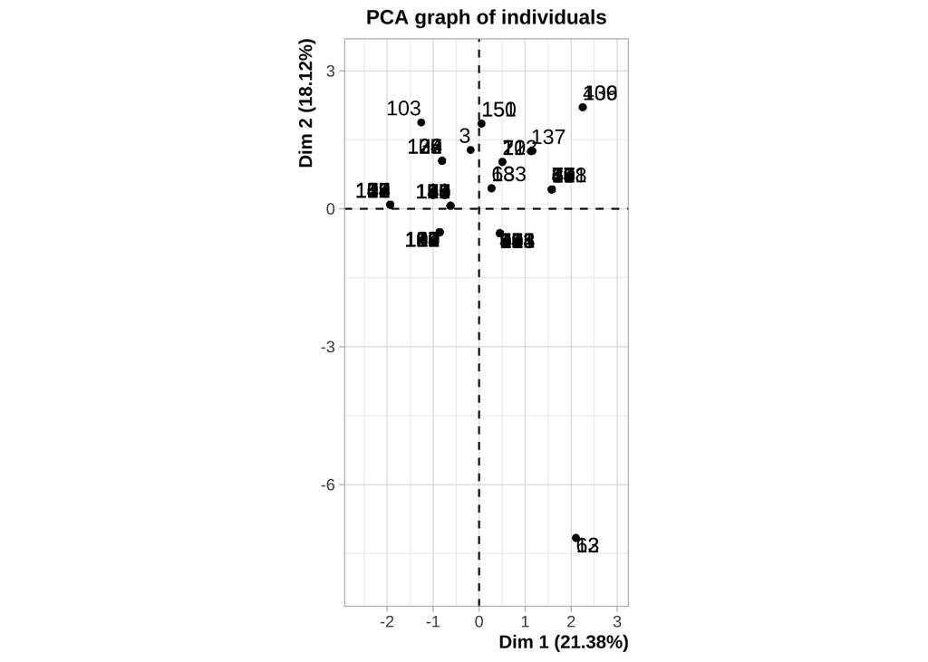

类似地，对其他地点各列进行主成分分析降维。降维后得到的前2个主成分结果如下。

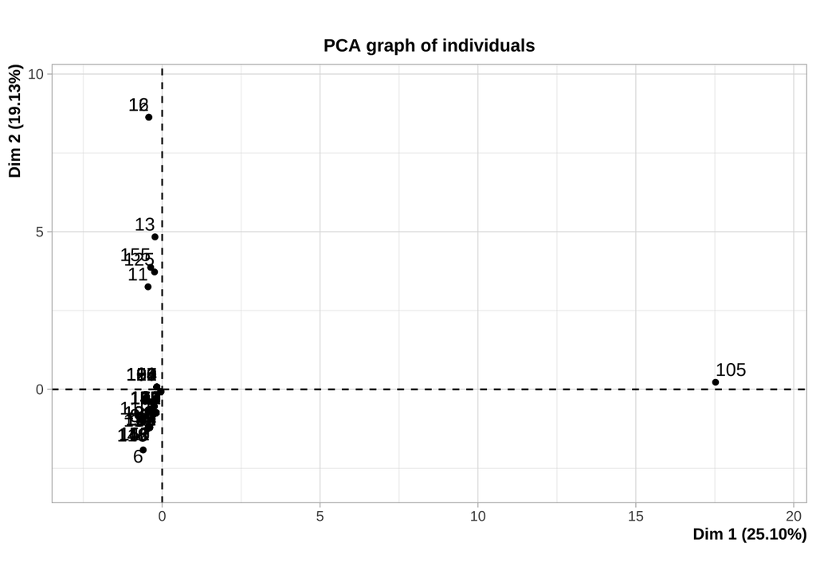

可见对于两组属性，前2个主成分都能够解释约40%的数据变异。因此，分别提取两组的两个主成分，结合其他属性，采用层次聚类法进行分类。结果参见"clust_res_3.png"和"clust_res_3.csv"。

## 比较方法2和3

我们会发现，方法2和方法3得到的结果有一定的相似性。那么，相似性有多大呢？Adjusted Rand Index可以表征两种分类结果一致性，越接近1则分类结果越相似。计算结果表明，方法2和方法3结果的Adjusted Rand Index = 0.62，表明一致性中等偏上。

我们可以看看它们的具体差异。下表中，行表示方法2的分类，列表示方法3的分类。可见，方法2中的32个案例，在方法3中约一半被分入第1类，一半被分入第4类；而第2类基本一致；第3类由一半一致；第4类看起来不一致，实际上有可能是因为方法2的第1类应该对应方法3的第4类，也就是说，大约有60%一致。

```
##
##      1  2  3  4
##   1 14  0  5 13
##   2  0 65  2  2
##   3  6  0 13  8
##   4 16  0  9  2
```

## 各类特点

那么如何表征各类别的特征呢？其中一个方法叫做对应分析。以方法3结果为例，可以得到下面这样的图。意味着类别2和固定大松明式关系更近，而4可能主要是篝火式、固定松明式、上げ松式。类似地，对于其他属性也可以做对应分析，以判断各个类别有何特点。因为有些小问题需要修复，且最好可以先决定一下采用方法2还是方法3，所以这部分未完待续。

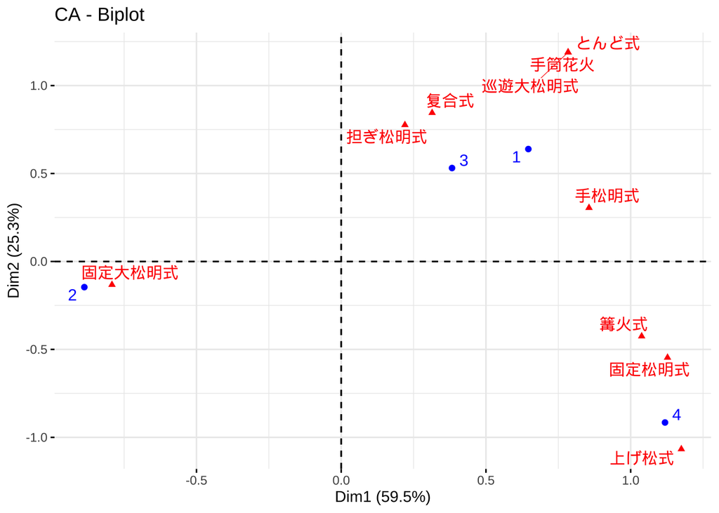